# Learning to marginalize latent discrete parameters

```r
library(magrittr)
```

```r
N <- 100 # total size of population
K <- 10 # total number of instances w/ features
M <- N - K # total number of instances w/o features
n <- 10 # number drawn from N w/o replacement
```

Our data comes from the [hypergeometric distribution](https://en.wikipedia.org/wiki/Hypergeometric_distribution) which describes the probability of observing $k$ successes – instances having some feature of interest – when $n$ instances are drawn from a population **without replacement** (this is key) of size $N = K + M$ where $K$ is the number of instances having the feature and $M$ is the number of instances without it.

That is, in a single trial $t$, the probability of drawing an instance from $K$ changes with each successive draw due to sampling without replacement.

```r
set.seed(0)
(y <- rhyper(nn = 5, m = K, n = M, k = n))
```

1. 2

2. 0

3. 1

4. 1

5. 2

## Model

Our model is specified as follows:

$$ y_t \sim \text{Hypergeometric}(K, M = N - K, n),~ t = 1, \ldots, T \\ K \sim \text{Binomial}(N, \theta) \\ \theta \sim \text{Beta}(\alpha, \beta) $$

where $N = 100, n = 10, T = 5$

### Prior

Using tinydensR addin, we find some values of $\alpha$ and $\beta$ for an informative prior on $\theta$ which formalizes our intuition that the proportion of instances with the feature in the population is pretty low:

[figure not shown]

## JAGS implementation

In JAGS 4.3.0, the hypergeometric distribution is specified as follows:

[figure not shown]

### Modeling

JAGS supports discrete latent parameters that we can sample directly, so it allows the most straightforward implementation of our model:

```
model {
  theta ~ dbeta(alpha, beta)
  K ~ dbinom(theta, N)
  M = N - K
  for (i in 1:T) {
    y[i] ~ dhyper(K, M, n, 1)
  }
}
```

```r
library(rjags)

jags_data <- list(y = y, T = length(y), N = N, n = n, alpha = 2, beta = 10)
jags_fit <- jags.model("model.jags", data = jags_data, n.chains = 4)
```

```
Linked to JAGS 4.3.0
Loaded modules: basemod,bugs
```

```r
jags_draws <- coda.samples(jags_fit, variable.names = c("theta", "K"), n.iter = 2000)
```

## Stan implementation

In Stan, we need to be a bit more explicit:

### Data

```
data {
  int<lower = 1> N;      // total population size
  int<lower = 1> n;      // sampled at a time w/o replacement
  int<lower = 1> T;      // number of trials
  int<lower = 0> y[T];   // observed w/ feature per trial
  real<lower = 0> alpha; // theta's prior's shape, positive
  real<lower = 0> beta;  // theta's prior's scale, positive
}
```

In preparation for modeling, we have to establish some limits on the values that `K` can take.

- `min_K` will be used as smallest possible value of `K` since Pr(K = k) = 0 for all k < min_K which means log Pr(K = k) = -Inf for all k < min_K and that's not great to deal with
- Similarly, if we grab `n` subjects in a trial and none of them have the feature, then `M` at minimum has to be `n`
- Consequently `K` can't be bigger than `N - n`

This is formalized as follows:

```
transformed data {
  // from data we know that K has to be at least the maximum observed:
  int<lower = 0, upper = n> min_K = max(y);
  int<lower = 0, upper = n> min_M = n - min(y);
  int<lower = 0, upper = N> max_K = N - min_M;
  // therefore we should explore this many possible values of K:
  int<lower = 0> Ks = max_K - min_K + 1;
}
```

### Modeling

[figure not shown]

So, in Stan: `n ~ hypergeometric(N, a, b)`

- `n`: observed w/ feature per trial, aka our `y[t]`
- `N`: sampled at a time w/o replacement, aka our `n`
- `a`: total number of subjects w/ features, aka our `K`
- `b`: total number of subjects w/o features, aka our `M`

#### Marginalization

Unlike JAGS (which samples via Gibbs), Stan (which samples via HMC) doesn't support discrete latent parameters, so those must be marginalized out and we must manually increment the log probability. This is explained in much better detail in [this chapter](https://mc-stan.org/docs/bayes-stats-stan/latent-discrete-chapter.html) of *Bayesian Statistics Using Stan*. The key principles (as I understand it) are:

- **conditional probabilities**: e.g. $p(y) = \sum_k p(y,k) = \sum_k p(y|k)p(k)$
- **log scale**: log of product becomes sum of logs, so we need only to keep adding to a cached log probability
- `log_sum_exp` function does some nice things that allow for stability & efficiency when adding on log scale

```
parameters {
  real<lower = 0, upper = 1> theta;
}

transformed parameters {
  vector[Ks] lp; // log probability cache
  lp = rep_vector(beta_lpdf(theta | alpha, beta), Ks);
  for (i in 1:Ks) {
    int k = i - 1 + min_K;
    int M = N - k;
    lp[i] += binomial_lpmf(k | N, theta);
    for (t in 1:T) {
      lp[i] += hypergeometric_lpmf(y[t] | n, k, M);
    }
  }
}

model {
  target += log_sum_exp(lp);
}
```

```r
suppressPackageStartupMessages(library(rstan))
options(mc.cores = 1)
rstan_options(auto_write = TRUE)
```

```r
stan_data <- jags_data # same values
stan_fit <- stan_model("model.stan", "marginalized_model")
stan_draws <- sampling(stan_fit, chains = 4, iter = 2000, data = stan_data, refresh = 0)
```

## Posterior of K

The following code processes the posterior samples into a form that can be combined with the results from Stan:

```r
jags_lp <- jags_draws %>%
  purrr::map(~ as.integer(.x[1000:2000, 1])) %>%
  purrr::reduce(c) %>%
  table %>%
  prop.table %>%
  log %>%
  as.data.frame %>%
  set_names(c("K", "log_prob")) %>%
  dplyr::mutate(K = as.integer(as.character(K))) %>%
  dplyr::filter(K <= 25)
```

The following code processes the outputted log probabilities by averaging over the draws:

```r
stan_lp <- stan_draws %>%
  rstan::extract(pars = "lp") %>%
  .$lp %>%
  as.data.frame %>%
  set_names(1:ncol(.)) %>%
  tidyr::gather(i, log_prob) %>%
  # map from i-index to k-values:
  dplyr::mutate(K = as.integer(i) + max(y) - 1) %>%
  dplyr::group_by(K) %>%
  dplyr::summarize(log_prob = median(log_prob)) %>%
  dplyr::filter(K <= 25)
```

Putting it all together:

```r
K_posterior <- dplyr::bind_rows(list(
  "JAGS (K sampled via Gibbs)" = jags_lp,
  "Stan (K marginalized out)" = stan_lp
), .id = "PPL")
```

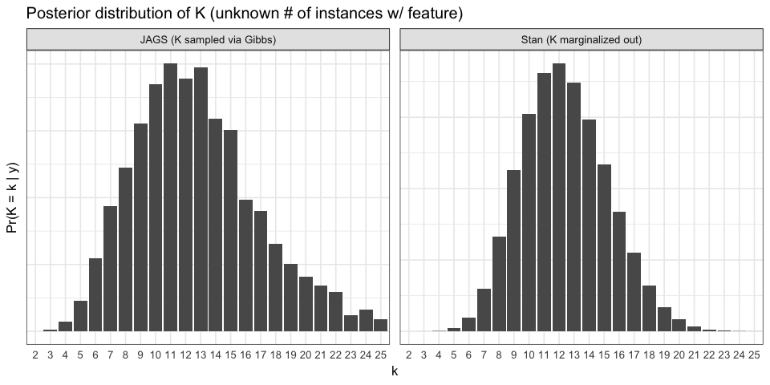

```r
library(repr)

options(repr.plot.width=8, repr.plot.height=4)

ggplot(K_posterior, aes(x = factor(K, 0:30), y = exp(log_prob))) +
  geom_col() +
  facet_wrap(~ PPL, scales = "free_y") +
  labs(
    title = "Posterior distribution of K (unknown # of instances w/ feature)",
    y = "Pr(K = k | y)", x = "k"
  ) +
  wmf::theme_facet(10) +
  theme(plot.subtitle = element_text(family = "mono")) +
  theme(axis.text.y = element_blank(), axis.ticks.y = element_blank())
```

# Corrections

There was a lot of trial-and-error since I haven't done this sort of thing in Stan before. Which means I'm still not 100% sure that I got it right but it looks right enough to me! If you have corrections/suggestions, feel free to email me at mikhail@wikimedia.org